# Predicting Titanic Passenger Survival

## Motivation & Preface

Building a prediction model that can accurately classify whether a Titanic passenger survived or perished, has plagued the greatest mathematical minds of our time. The construction of such a model would be an incredible statistical achievement and offer unimaginable benefits to society. For these reasons, I decided to take on this behemoth of a task.  
Alright, maybe I’m embellishing just a bit. We already know who survived the sinking of the Titanic, meaning it would not be difficult to cheat and build a model with 100% accuracy. Yet, for some reason I spent a week building a prediction algorithm that is correct for only 80% of passengers.

The purpose of this reproducible report is to showcase *a very particular set of skills that I have acquired over the last several months. Skills which would make me a dream candidate for people like you.*

The main skill I hope to demonstrate with this report is my mastery of the statistical programming language R. This includes writing complex functions, creating stunning visuals, conducting appropriate statistical tests, and employing advanced machine learning algorithms. This whole report, along with the accompanying `shiny` widget were both created entirely in R.

I would also hope this report demonstrates some level of sound analytic ability on my part, though I did admittedly just spend a week building a model that predicts an outcome that’s been known for over a century. That by itself, should bring my analytic judgment into question, so I guess I have an uphill battle if I want to convince you otherwise. See you at the summit!

## Competition Details

The competition is run by [Kaggle](http://www.kaggle.com/c/titanic-gettingStarted). They give you detailed information on 891 passengers including whether they survived or not. Your task is to build a model based on these 891 passengers to predict if a different group of 418 passengers survived.

[The Leaderboard](http://www.kaggle.com/c/titanic-gettingStarted/leaderboard) is ranked by how accurately you predicted half the test set. At the end of the competition they will release accuracy rankings on the full test set. Because it is easy to look up whether a passenger survived or perished, several contestants inflated their results. According to consensus among competitors the best models push only about 82% accuracy, so anything above that is a dubious result.

My final model predicted 79.5% correctly which was good enough for top 20% when I submitted. Since that is accuracy on only half the test set, final rankings tend to vary a lot, and so I am very pleased with my result and am reasonably confident my ranking will improve when the entire test set accuracy is considered. The rest of this report will walk you through how I obtained that result, while showcasing my proficiency with R.

I doubt you have the time or the interest to examine the whole report, but peruse the sections that seem particularly interesting or revealing.

## Data Preprocessing

There are an abundance of algorithms available to use when building predictive models, and they each have their own supporters, but from what little experience I have, what matters most is the data you feed each model. The maxim “garbage in, garbage” out holds true for any algorithm you use. I therefore spend the majority of my time preprocessing data and determining which variables are worth including in models. Certain algorithms will conduct automatic feature selection, but by conducting my own feature selection, I can avoid spurious variable relationships much more confidently.

### Loading the Data

First things first; we need to read-in the data. Missing data is listed as either NA or left blank, so I specify that when loading the data.

```r
setwd("Kaggle/Titanic")
rawData <- read.csv("train.csv", stringsAsFactors = FALSE, na.strings = c(NA, ""))
```

After reading in the data, the next thing to do is get a feel for what variables you have to work with. I like to use `head(data)` or `str(data)` to best get a feel for the data. Here I use `str()`.

```r
str(rawData)
```

```
## 'data.frame':    891 obs. of  12 variables:
##  $ PassengerId: int  1 2 3 4 5 6 7 8 9 10 ...
##  $ Survived   : int  0 1 1 1 0 0 0 0 1 1 ...
##  $ Pclass     : int  3 1 3 1 3 3 1 3 3 2 ...
##  $ Name       : chr  "Braund, Mr. Owen Harris" "Cumings, Mrs. John Bradley (Florence Briggs Thayer)" "Heikkinen, Miss. Laina" "Futrelle, Mrs. Jacques Heath (Lily May Peel)" ...
##  $ Sex        : chr  "male" "female" "female" "female" ...
##  $ Age        : num  22 38 26 35 35 NA 54 2 27 14 ...
##  $ SibSp      : int  1 1 0 1 0 0 0 3 0 1 ...
##  $ Parch      : int  0 0 0 0 0 0 0 1 2 0 ...
##  $ Ticket     : chr  "A/5 21171" "PC 17599" "STON/O2. 3101282" "113803" ...
##  $ Fare       : num  7.25 71.28 7.92 53.1 8.05 ...
##  $ Cabin      : chr  NA "C85" NA "C123" ...
##  $ Embarked   : chr  "S" "C" "S" "S" ...
```

`str` is useful because it summarizes each column and tells us its class. Right away I notice that there are several incorrectly coded columns and a **PassengerID** column that is unnecessary. We can fix all of these with one call to the `transform` function. As a personal preference I like my column names lowercase, so I change that as well using the `tolower` function.

```r
colnames(rawData) <- tolower(colnames(rawData))

rawData <- transform(rawData, sex = factor(sex, levels = c("male", "female")),
                              pclass = factor(pclass, ordered = TRUE, levels = c(3, 2, 1)),
                              embarked = factor(embarked),
                              survived = factor(survived),
                              passengerid = NULL)
```

Note that I change **pclass** (passenger social class) to an ordered factor, because there is a natural order to the classes(first class > second > third), but I don’t do that for the other factor variables, because there is no natural ordering. Speaking of **pclass**, keep in mind that it represents a passenger’s social class and not their cabin level. For example a passenger with **pclass** equal to 1, may very well have been traveling in the hull of the ship with the cargo, if they were frugal enough.

### Dealing with Missing Data

The bane of anyone conducting statistical analysis or building prediction models is missing data, so I rip the bandage off earlier rather than later and see just how much data is missing. The following function returns each column’s proportion of missing data by using a combination of the `apply`, `nrow` and the logical function `is.na`.

```r
options(digits=2)
apply(rawData, 2, function(x) sum(is.na(x))/nrow(rawData))
```

```
## survived   pclass     name      sex      age    sibsp    parch   ticket
##   0.0000   0.0000   0.0000   0.0000   0.1987   0.0000   0.0000   0.0000
##     fare    cabin embarked
##   0.0000   0.7710   0.0022
```

Not terrible results. 20% of **age** values are missing, 0.2% of the cities a passenger departed from are absent, and 77.1% of cabin numbers are also AWOL. With 77.1% of cabin numbers missing, there is no way to accurately impute the missing data, so cabin number will have to be ignored.

Normally to impute missing data I would use KNN imputation, but with this data set there is a better way. Note that in the **name** column, we also have a passenger’s title. These titles are directly linked to the passenger’s age, and since we have titles for each passenger, we can confidently predict age. First though we need to extract the **passTitle** variable from **name.**

To do this I use the `str_split` function in the **stringr** package in conjunction with the `sapply` function.

```r
splitNames <- str_split(rawData$name, ",")
splitNames <- sapply(splitNames, "[[", 2)
passTitle <- sapply(splitNames, function(x) str_split(x, " ")[[1]][2])
names(passTitle) <- NULL
passTitle <- factor(passTitle)
levels(passTitle)
```

```
##  [1] "Capt."     "Col."      "Don."      "Dr."       "Jonkheer."
##  [6] "Lady."     "Major."    "Master."   "Miss."     "Mlle."
## [11] "Mme."      "Mr."       "Mrs."      "Ms."       "Rev."
## [16] "Sir."      "the"
```

The only class incorrectly labeled was “the”, which after locating in the data set is supposed to be “the Countess”, so I make that change. I also calculate the frequency of each title.

```r
theIndex <- which(passTitle == "the")
splitNames[[theIndex]]
```

```
## [1] " the Countess. of (Lucy Noel Martha Dyer-Edwards)"
```

```r
passTitle <- revalue(passTitle, c(the = "Countess"))
summary(passTitle)
```

```
##     Capt.      Col.      Don.       Dr. Jonkheer.     Lady.    Major.
##         1         2         1         7         1         1         2
##   Master.     Miss.     Mlle.      Mme.       Mr.      Mrs.       Ms.
##        40       182         2         1       517       125         1
##      Rev.      Sir.  Countess
##         6         1         1
```

No model is going to handle classes that appear so infrequently very well, so I decided to combine classes. Miss, Ms. and Mlle. are all equivalent, as are Mrs. and Mme., so I combine those two sets. I also grouped the nobility honorifics into one category and the military titles (including the captain) into another. I left doctors and reverends alone, because they didn’t nicely fit into another category. Here’s the code to do that:

```r
passTitle <- revalue(passTitle, c(Mlle. = "Miss.", Ms. = "Miss."))
passTitle <- revalue(passTitle, c(Mme. = "Mrs."))
passTitle <- revalue(passTitle, c(Capt.  = "Military.",
                                  Col.   = "Military.",
                                  Major. = "Military."))
passTitle <- revalue(passTitle, c(Sir.      = "Nobility.",
                                  Lady.     = "Nobility.",
                                  Don.      = "Nobility.",
                                  Countess  = "Nobility.",
                                  Jonkheer. = "Nobility."))
summary(passTitle)
```

```
## Military. Nobility.       Dr.   Master.     Miss.      Mrs.       Mr.
##         5         5         7        40       185       126       517
##      Rev.
##         6
```

```r
rawData <- data.frame(rawData, passTitle)
```

I’d prefer to have slightly better balance between classes, but that will have to do.

With title added we can now attempt to impute **age** using the `mean` **age** of each **passTitle** subgroup. Let’s calculate the mean and standard deviation of each title, to get an idea of whether or not **passTitle** truly does indicate age.

```r
titleMean <- with(rawData, tapply(age, passTitle, mean, na.rm = TRUE))
titleSD <- with(rawData, tapply(age, passTitle, sd, na.rm = TRUE))
data.frame(mean = titleMean, SD = titleSD)
```

```
##           mean   SD
## Military. 56.6  9.3
## Nobility. 41.6  6.8
## Dr.       42.0 12.0
## Master.    4.6  3.6
## Miss.     21.8 12.9
## Mrs.      35.8 11.4
## Mr.       32.4 12.7
## Rev.      43.2 13.1
```

I am worried about differentiating children from adults, because from previous knowledge I know women and children generally made it off the Titanic. If a class is clearly all adults, I don’t care if predicted **age** is slightly inaccurate (e.g. labeling a doctor 42 years old, when really he was 32). However, for classes with mean **age** close to minor status (mean **age** under 25 years old) inaccurate age predictions will confuse the modeling process.

The only **passTitle** where this is the case is *Miss*, which is the title given to unmarried women of any age, therefore I am hesitant to lump all Misses, whose ages are missing together. Let’s further examine the distribution of age, given the **passTitle** *Miss*, with a histogram.

```r
library(knitr)
missIndex <- which(rawData$passTitle == "Miss.")
missHist <- rPlot(x="bin(age,1)",
                  y="count(age)",
                  data=rawData[missIndex, ],
                  type="bar")
missHist$guides(x=list(title="Age (Years)"),
                y=list(title="Count"))
missHist$set(title = "Age Distribution of 'Miss' Passengers")
missHist$show('inline', include_assets = TRUE)
```

[output not shown]

We have a variable **parch**, which represents the number of parents or children you are traveling with. We know that in the early 1900s the chances that a woman was unmarried and had a child, were relatively slim, so any positive **parch** to me indicates that individual was traveling with parents and would therefore be younger. Using the `aggregate` function, we can test this theory.

```r
aggregate(age ~ parch, data = rawData[missIndex, ], FUN = mean, na.rm = TRUE)
```

```
##   parch  age
## 1     0 27.7
## 2     1  9.9
## 3     2 13.4
```

Clearly those with positive **parch** values are much younger. For the Miss category we now have a way of imputing **age**, based on whether or not a passenger was traveling with parents. Now we can finally impute the missing ages for those 20% of passengers without an **age** value. The code for doing this is fairly ad hoc, so no need to follow all of it, but it essentially does the following:

1. Selects the passengers with missing ages
2. If passengers have a **passTitle** other than “Miss.”, impute using the mean of that title
3. If their title is “Miss.”, subset by **parch** and impute age using the mean of these subgroups

```r
# Create a reference table of Passenger Title and Average Age
titleAge <- with(rawData, tapply(age, passTitle, mean, na.rm = TRUE))
titleAge <- data.frame(title = levels(rawData$passTitle), age = titleAge)
titleAge[which(titleAge$title == "Miss."), 2] <- NA

# Index the missing ages and impute, unless title is Miss
noAgeIndex <- which(is.na(rawData$age))
matchIndex <- match(rawData$passTitle[noAgeIndex], titleAge$title)
rawData$age[noAgeIndex] <- titleAge$age[matchIndex]

# Create a reference table of Parch values and Age, for those titled Miss
noAge2 <- which(is.na(rawData$age))
parchMissAge <- aggregate(age ~ parch, data = rawData[missIndex, ],
                          FUN = mean, na.rm = TRUE)
matchIndex2 <- match(rawData$parch[noAge2], parchMissAge$parch)
rawData$age[noAge2] <- parchMissAge$age[matchIndex2]
```

Essentially all I did was create two reference tables of **passTitle** vs. **age**, and **parch** vs. **age** for those titled Miss. I then matched titles and imputed the matched **age** for the passengers with unknown values. Voila, not too difficult.

Now let’s make sure we imputed ages for everyone.

```r
options(digits=2)
apply(rawData, 2, function(x) sum(is.na(x)))
```

```
##  survived    pclass      name       sex       age     sibsp     parch
##         0         0         0         0         0         0         0
##    ticket      fare     cabin  embarked passTitle
##         0         0       687         2         0
```

Two passengers are still missing their boarding city. I might wager that passenger title is correlated with which city you departed from, so let’s obtain the pair’s titles.

```r
missingIndexEmb <- which(is.na(rawData$embarked))
rawData$passTitle[missingIndexEmb]
```

```
## [1] Miss. Mrs.
## Levels: Military. Nobility. Dr. Master. Miss. Mrs. Mr. Rev.
```

Now we can use the `prop.table` function to analyze the relationship between title and city departed. For one individual their title is Miss. and for the other they had the title Mrs., from the table we can see that they have a 60% and 72% chance of departing from Southampton

```r
round(with(rawData, prop.table(table(passTitle, embarked), 1)),2)
```

```
##            embarked
## passTitle      C    Q    S
##   Military. 0.20 0.00 0.80
##   Nobility. 0.60 0.00 0.40
##   Dr.       0.29 0.14 0.57
##   Master.   0.12 0.10 0.78
##   Miss.     0.22 0.18 0.60
##   Mrs.      0.26 0.02 0.72
##   Mr.       0.16 0.07 0.77
##   Rev.      0.00 0.17 0.83
```

For our two individuals, they had a 60 and 72% chance respectively of departing from Southampton, so we can assign them both to have departed from Southampton.

```r
rawData$embarked[missingIndexEmb] <- "S"
```

### Taking Preprocessing a Step Further

There are four more improvements I’d like to make to the predictors before I actually build the final model. Here’s what I’d like to do:

1. Convert **sibsp** into two separate variables
- Number of Siblings
- Traveling with Spouse
2. Convert **parch** into two separate variables
- Number of Parents
- Number of Children
3. Last Name Variable, so as to make the following variables:
- Number of family members that died
- Number of family members that lived
4. Individual Fare (currently summed for each group)

#### 1. Decompose **sibsp**

Separating out **sibsp** into siblings or spouse was one of the bigger challenges of the project, because for a lot of cases there was no definitive answer. I ended up using a combination of the other variables to predict whether they had a sibling(s), spouse, or both.

The code, is again pretty ad hoc, but I provide it to show my ability to use a variety of functions in R. The comments provide my rationale for each step.

```r
# Create two new variables, siblings and spouse, which will be derived from sibsp
rawData$siblings <- rep(NA,nrow(rawData))
rawData$spouse  <- rep(NA,nrow(rawData))

# In order to deconstruct sibsp, we will need some rules
# The youngest marriage is 14, so 13 or younger sibsp = siblings
sort(rawData$age[which(rawData$passTitle=="Mrs.")])
rawData$siblings <- with(rawData, ifelse(age<14,sibsp,NA))
rawData$spouse <- with(rawData, ifelse(age<14,0,NA))

# The same logic applies to those with the title, Rev, Miss, and Master (unmarried)
rmmIndex <- with(rawData,(which(passTitle == "Rev." |
                                passTitle == "Miss." |
                                passTitle ==  "Master.")))
rawData$siblings[rmmIndex] <- rawData$sibsp[rmmIndex]
rawData$spouse[rmmIndex] <- 0

# For 'Mrs.' the name variable is coded with husband's name & her's in parenthesis
# so presence of a "(" indicates traveling with spouse
mrsIndex <- with(rawData,(which(passTitle == "Mrs.")))
husbandIndex <- grepl(pattern = "\\(", rawData$name[mrsIndex])
rawData$siblings[mrsIndex][husbandIndex] <- pmax(I(rawData$sibsp[mrsIndex][husbandIndex]-1),0)
rawData$siblings[mrsIndex][!husbandIndex] <- rawData$sibsp[mrsIndex][!husbandIndex]
rawData$spouse[mrsIndex][husbandIndex]  <- ifelse(rawData$sibsp[mrsIndex][husbandIndex]==0,0,1)
rawData$spouse[mrsIndex][!husbandIndex] <- 0

# For 'Mr.' if 19 or younger, doubtful married
youngMrIndex <- with(rawData,(which(passTitle == "Mr." & age < 20)))
rawData$siblings[youngMrIndex] <- rawData$sibsp[youngMrIndex]
rawData$spouse[youngMrIndex] <- 0

# For 'Mr.' 20 or older, if sibsp = 1 I assume that 1 is a spouse, otherwise...
# ...if they have parch > 0, assume they have a spouse, otherwise...
# ...assume unmarried
oldMrIndex <- with(rawData, (which(passTitle == "Mr." & age >= 20 & sibsp > 0)))

rawData$spouse[oldMrIndex] <- with(rawData[oldMrIndex,], (ifelse(sibsp == 1,1,
                                                    ifelse(parch > 0, 1, 0))))
rawData$siblings[oldMrIndex] <- with(rawData[oldMrIndex,],
                                     (ifelse(sibsp == 1, 0,
                                             ifelse(parch > 0,
                                                    I(sibsp-1), sibsp))))
unmarMrIndex <- with(rawData,(which(passTitle == "Mr." & age >= 20 & sibsp == 0)))
rawData$spouse[unmarMrIndex]   <- 0
rawData$siblings[unmarMrIndex] <- 0

# For Dr., Military, and Nobility, same thing as for Mr.:
# If sibsp = 1, I assume traveling with spouse, if more than 1, I check for kids,
# If they have kids, then traveling with spouse, if no kids, no spouse
dmnIndex <- with(rawData, (which( passTitle =="Military." |
                                    passTitle == "Nobility." |
                                    passTitle ==  "Dr.")))
aloneIndex <- with(rawData[dmnIndex,], (which(sibsp == 0)))

rawData$siblings[dmnIndex][aloneIndex] <- 0
rawData$spouse[dmnIndex][aloneIndex] <- 0
rawData$spouse[dmnIndex][-aloneIndex] <- with(rawData[dmnIndex,][-aloneIndex,],
                                                (ifelse(sibsp == 1,1,
                                                        ifelse(parch > 0, 1, 0))))

rawData$siblings[dmnIndex][-aloneIndex] <- with(rawData[dmnIndex,][-aloneIndex,],
                                            (ifelse(sibsp == 1, 0,
                                                    ifelse(parch > 0,
                                                           I(sibsp-1), sibsp))))
```

Now we can remove **sibsp** from the predictor set.

```r
# Now we can remove the sibsp variable
rawData$sibsp <- NULL
```

#### 2. Decompose **parch**

```r
# Create new parents and children variables
rawData$parents  <- rep(NA,nrow(rawData))
rawData$children <- rep(NA,nrow(rawData))
```

I was hoping that no one between the ages of 16-19, would have a positive parch value, because it is ambiguous if they are the parent or the child, so let’s check. The problem range is in red.

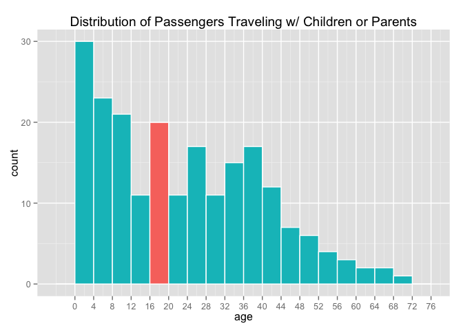

```r
parchIndex <- which(rawData$parch > 0)
problemCohort <- with(rawData[parchIndex, ],
                       ifelse(age > 15 & age < 20 & parch > 0, 0, 1))

ggplot(data=rawData[parchIndex, ], aes(x=age, fill = factor(problemCohort))) +
    geom_histogram(binwidth=4, color = "white") +
    scale_x_continuous(breaks = seq(0,78,by=4)) +
    ggtitle("Distribution of Passengers Traveling w/ Children or Parents") +
    guides(fill=FALSE)
```

I was hoping that group wouldn’t be large, but of course they were. I therefore used the following decisions to determine if the **parch** value represented a parent aboard or a child.

1. If older then 20, **parch** indicates traveling with your child(ren)
2. If younger than 16, **parch** indicates traveling with parent(s)
3. If between ages 16 and 21, then assuming traveling with parent, unless:
- Married (**passTitle** is Mrs. or you have a spouse aboard)

```r
# Create aforementioned indices
parchIndex2 <- with(rawData, which(age > 16 & age < 21 & parch > 0))
parchIndexKid <- with(rawData, which(age <= 16 & parch > 0))
parchIndexParent <- with(rawData, which(age >= 21 & parch > 0))

# Assign correct values
rawData$parents[parchIndexKid] <- rawData$parch[parchIndexKid]
rawData$children[parchIndexKid] <- 0
rawData$parents[parchIndexParent] <- 0
rawData$children[parchIndexParent] <- rawData$parch[parchIndexParent]
rawData$children[parchIndex2] <- with(rawData[parchIndex2, ],
                                     ifelse(passTitle=="Mrs." | spouse == 1,
                                            parch, 0))
rawData$parents[parchIndex2] <- with(rawData[parchIndex2, ],
                                      ifelse(passTitle=="Mrs." | spouse == 1,
                                             0, parch))

# Set parents and children to 0 for everyone else
rawData$parents[-parchIndex] <- 0
rawData$children[-parchIndex] <- 0

# Make sure both new columns are complete
apply(rawData, 2, function(x) { sum(is.na(x))/nrow(rawData) })
```

```
##  survived    pclass      name       sex       age     parch    ticket
##      0.00      0.00      0.00      0.00      0.00      0.00      0.00
##      fare     cabin  embarked passTitle  siblings    spouse   parents
##      0.00      0.77      0.00      0.00      0.00      0.00      0.00
##  children
##      0.00
```

```r
# No longer need parch column
rawData$parch <- NULL
```

#### 3. Create Last Name Variable and Tabulate if Family Members Survived

There is a function `word` in the **stringr** package which will easily grab the last name of each passenger.

```r
rawData$lastname <- word(rawData$name, sep = fixed(","))
```

Now the tricky part is matching family members by last name and then coding new variables for if they survived or not. I wrote a `for` loop to accomplish this. Generally I avoid `for` loops in R, because they aren’t as fast as vectorized operations, but sometimes they are unavoidable.

```r
for (i in 1:nrow(rawData)) {
    sameNameIndex <- with(rawData,(grep(lastname[i],lastname[-i],fixed=TRUE)))+1
    rawData$familylived[i] <- ifelse(length(sameNameIndex) == 0, 0,
                                     sum((as.numeric(rawData$survived[sameNameIndex])-1)))
    rawData$familydied[i] <- ifelse(length(sameNameIndex) == 0, 0,
                                    sum((-1*as.numeric(rawData$survived[sameNameIndex]))+2))
}
```

That function isn’t incredibly complicated when I explain what it does in words, so here goes.

For each row:

1. Find all the rows that share a last name (excluding itself) and index them
2. If there are rows that share a last name, sum the total who lived for **familylived** variable
3. If there are rows that share a last name, sum the total who died for **familydied** variable
4. If no rows shared a last name, set the above two variables to 0

#### 4. Correct Fare

Compared to the other created variables calculated correct fare should be a breeze. All that needs to be done is divide total group fare, by the number of passengers in each group, which we now have a decent proxy for (1+spouse+siblings+parents+children).

```r
rawData$travelerfare <- with(rawData, (fare/(1+spouse+siblings+parents+children)))
```

### Removing Unnecessary Predictors

**Name** and **lastname** are no longer helpful. **Ticket** is coded differently for numerous passengers, making it uninterpretable. **Cabin** has 77% missing values. Therefore I remove all these predictors. Finally I verify the class of each predictor. I notice that spouse can be coded as a dummy variable, because no passengers to my knowledge was traveling with multiple spouses.

```r
tidyData <- rawData
tidyData$name <- NULL
tidyData$lastname <- NULL
tidyData$ticket <- NULL
tidyData$cabin <- NULL

# Correct classes
tidyData$spouse <- as.factor(tidyData$spouse)
```

And finally we have a tidy data set with columns that I consider to have some level of predictive power. Now the fun part: exploring the data.

## Exploring the Data

Let’s first look at the relationship between the categorical variables and passenger fate. Once we know these relationships, we can explore the numeric predictors relationships, to fill any gaps.

### Categorical Predictors

The first thing I’d like to do is visualize the proportion who survived, broken down by each factor variable. The following code accomplishes just that.

```r
catIndex <- sapply(tidyData, is.factor)
trainingCat <- tidyData[, catIndex]
trainingCat$survived <- revalue(trainingCat$survived, c("0" = "Died", "1" = "Survived"))
catIndex
```

```
##     survived       pclass          sex          age         fare
##         TRUE         TRUE         TRUE        FALSE        FALSE
##     embarked    passTitle     siblings       spouse      parents
##         TRUE         TRUE        FALSE         TRUE        FALSE
##     children  familylived   familydied travelerfare
##        FALSE        FALSE        FALSE        FALSE
```

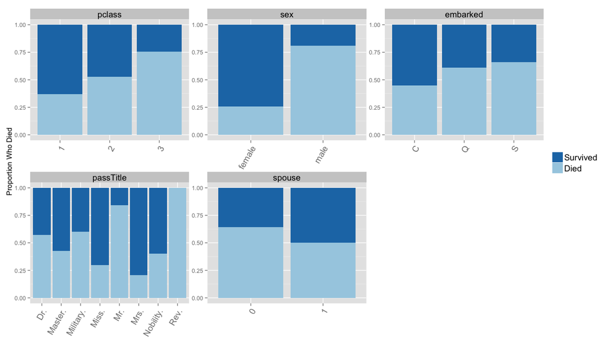

```r
# Visualize Relationships with Stacked Bar Chart
catMelt <- melt(trainingCat, id = "survived")
ggplot(data = catMelt, aes(x = factor(value), fill = factor(survived))) +
    geom_bar(position = "fill") +
    facet_wrap(~variable, scales = "free") +
    scale_fill_brewer(palette = "Paired") +
    guides(fill = guide_legend(reverse = TRUE)) +
    theme(axis.text.x = element_text(size=14, angle = 60,
                                     vjust = 1, hjust = 1),
          strip.text.x = element_text(size = 14),
          legend.text=element_text(size=14),
          legend.title=element_text(size=0)) +
    scale_x_discrete(name = "") +
    scale_y_continuous(name = "Proportion Who Died")
```

There is a lot to take away from this graph. Some should be expected, some maybe not.

1. Women survived much more frequently than men.
2. A passenger’s social class played a large role in survival chances.
3. Those with spouses survived more than unmarried individuals.
4. The city where you departed from appears related to survival rates.
5. Title appears to have an impact.

The problem with this analysis is that several of these variables are correlated. For example title obviously indicates gender, so let’s also examine some relationships when we allow for interaction.

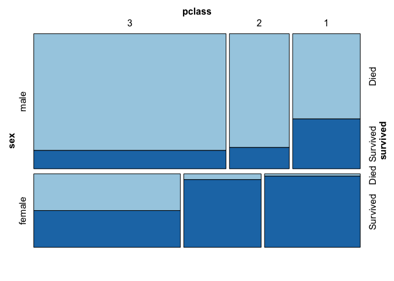

```r
mosaic(survived ~ sex + pclass, data = trainingCat,
       highlighting_fill=c("#a6cee3","#1f78b4"))
```

`mosaic` in the **vcd** package is a fantastic function for displaying interaction between different categorical variables. From the graph, if you were a woman from the first or middle class, you had nearly a 100% chance of surviving, versus a woman who came from the third class, who had approximately a 50% chance of surviving.  
Men’s chances were not as good as any subgroup of women, but first class men, had about a 35-40% chance of surviving, versus a 10-15% chance for those in lower classes. It is interesting that going from third to middle/second class, greatly increased a woman’s chance or survival, but not a man’s.

Any highly accurate model, will need to depict these relationships. Let’s examine a few more variable relationships using `mosaic`.

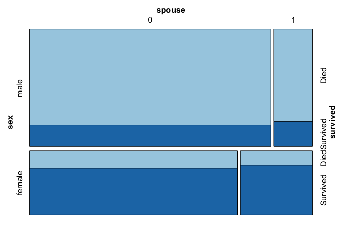

```r
mosaic(survived ~ sex + spouse, data = trainingCat,
       highlighting_fill=c("#a6cee3","#1f78b4"))
```

When we control for gender, the relationship between surviving and traveling with a spouse, goes completely away. It just so happened that more women were traveling with a spouse than men, making it look like traveling with a spouse had an impact.

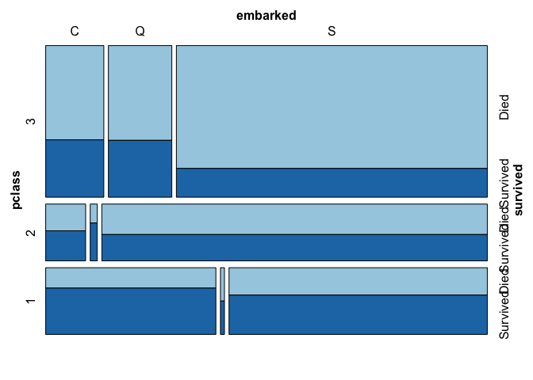

```r
mosaic(survived ~ pclass + embarked, data = trainingCat,
       highlighting_fill=c("#a6cee3","#1f78b4"))
```

I was skeptical that the city a passenger departed from (Southampton, Queenstown, or Cherbourg) would have any impact on the chance of survival, but if you were a third class passenger your chances of survival were nearly double if you didn’t board in Southhampton. I was still skeptical of the relationship, so I also added gender to the plot.

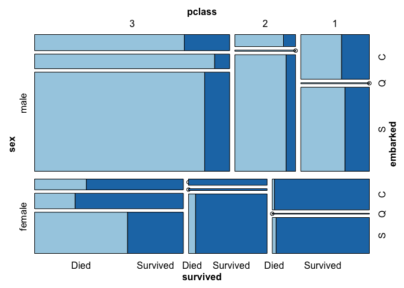

```r
mosaic(survived ~ sex + pclass + embarked, data = trainingCat,
       highlighting_fill=c("#a6cee3","#1f78b4"))
```

When you have 3+ variables mosaic can be confusing, but if you limit your viewing to the lower left-hand quadrant, it is clear that third class women had much better odds of survival if they boarded at Queenstown or Cherbourg.

This makes city departed from seem like an important variable to include in models, however I want to check to make sure the sample in each of these groups is large enough to bolster confidence in this relationship. For example if there were only 3 3rd class women who departed from Queenstown, this relationship would become more dubious.

```r
aggTable <- aggregate(survived ~ embarked + sex + pclass, data = trainingCat,length)
names(aggTable)[4] <- "count"
aggTable[4:6,]
```

```
##   embarked    sex pclass count
## 4        C female      3    23
## 5        Q female      3    33
## 6        S female      3    88
```

We see that there were 88 women who departed from Southhampton, and from the mosaic plot above, only roughly a third of them survived. The other two subgroups of women had survival rates well above 50%, clearly there is something to this. My best guess is that these passengers were in a section of the ship that was far from the lifeboats, and so I will include embarked city in the model building process.

Here are the biggest takeaways from the categorical portion of my exploratory data analysis that any accurate model will need to encompass:

1. Women survived much more frequently than men.
2. Third-class women had much worse odds of survival than their counterparts in the first or second class.
3. Among women in the third class, departing from Southampton greatly reduced odds of survival.
4. First class men had much better odds of survival than second or third-class men.
5. Marital status doesn’t affect survival, after controlling for gender.

Next I analyze the numeric variables and their correlations with survival rates.

### Numeric Predictors

There were two groups of passengers categorical variables did not do a great job at predicting survival for: first class men and third class women. Let’s see if the 5 numeric predictors can explain these subgroups better.

#### First Class Men

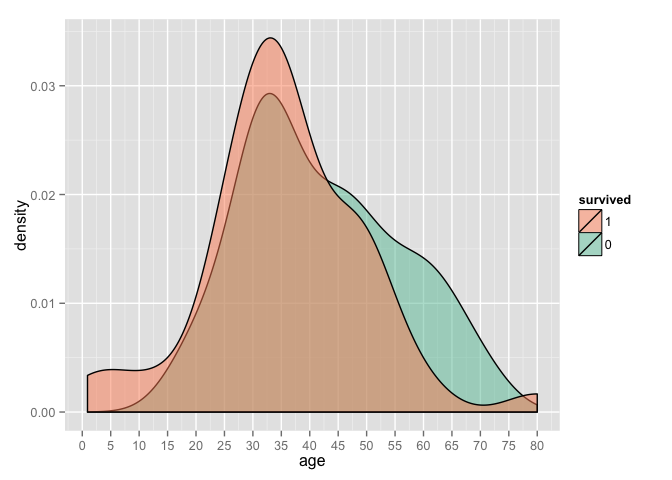

```r
tidyDataMen <- tidyData[which(tidyData$sex == "male" & tidyData$pclass == "1"), ]
legFlip   <-  guides(fill=guide_legend(reverse = TRUE))
histColor <- scale_fill_brewer(palette = "Set2")

ggplot(data = tidyDataMen, aes(x = age, fill = survived)) +
    geom_density(alpha=0.5) + scale_x_continuous(breaks = seq(0,80,by=5)) +
    histColor + legFlip
```

Not very much of a difference in the distribution of **age** between first class men who survived and those who didn’t. The most obvious takeaway is that boys roughly 10 or under made up a larger portion of the first class male survivors than of their casualties.

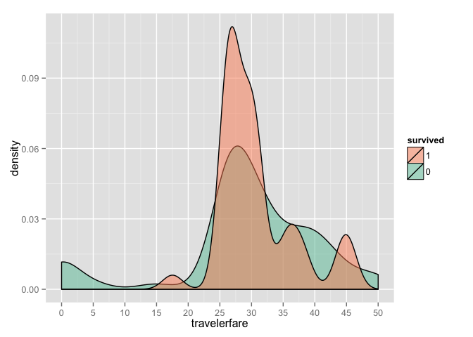

```r
ggplot(data = tidyDataMen, aes(x = travelerfare, fill = survived)) +
    geom_density(alpha=0.5) + histColor + legFlip +
    scale_x_continuous(breaks = seq(0,80,by=5), limits = c(0, 50))
```

**Fare** doesn’t seem to impact survivability of first class men, namely because it appears that the majority of these men paid the same fare (just under $30). There does appear to be a portion of rich men who paid really low fares, and they all died, so fare may provide some value to our models.

Next let’s take a look at how traveling with **parents** affected survival odds for first class male passengers.

```r
parTable <- table(tidyDataMen$parents,tidyDataMen$survived)
colnames(parTable) <- c("Perished","Survived")
pardf<- data.frame(parents = rownames(parTable), parTable)
```

```r
n1 <- nPlot(Freq ~ parents, group = 'Var2', data = pardf, type = 'multiBarChart')
n1$yAxis(axisLabel = "Count" )
n1$chart(margin = list(left = 75))
n1$xAxis(axisLabel = "Number of Parents")
n1$show('inline', include_assets = TRUE)
```

[output not shown]

Unfortunately this severe class imbalance plagues the other numeric variables as well (not visualized: **siblings**, **children**, **familylived** & **familydied**) meaning their graphs aren’t worth showing.

Most numeric predictors didn’t do a great job at discerning if a first class male passenger survived, however survival odds do seem tied to if you are under 10 years old or if you paid a low fare.

#### 3rd Class Women

Third class women survived about 50% of the time. Hopefully the numeric predictors can provide insight into what demographic characteristics impacted who among this group survived.

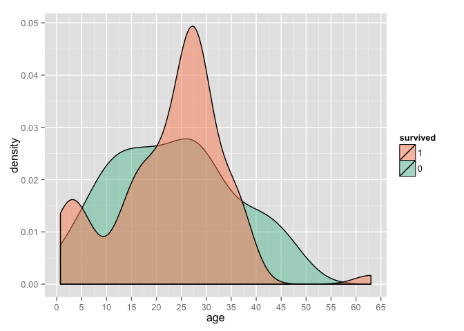

```r
tidyDataWomen <- tidyData[which(tidyData$sex == "female" &
                                    tidyData$pclass == "3"), ]

ggplot(data = tidyDataWomen, aes(x = age, fill = survived)) +
    geom_density(alpha=0.5) + scale_x_continuous(breaks = seq(0,80,by=5)) +
    histColor + legFlip
```

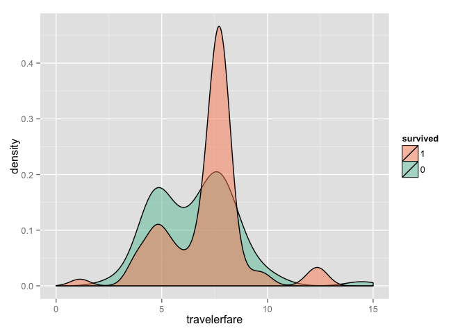

```r
ggplot(data = tidyDataWomen, aes(x = travelerfare, fill = survived)) +
    geom_density(alpha=0.5) + histColor + legFlip +
    scale_x_continuous(breaks = seq(0,80,by=5), limits = c(0, 15))
```

3rd class fares for women seem bimodal at $5 and $8. Those paying the higher fare, look to have had much better odds of survival.

```r
famTable <- table(tidyDataWomen$familydied,tidyDataWomen$survived)
colnames(famTable) <- c("Perished","Survived")
famdf<- data.frame(fam = rownames(famTable), famTable)
```

```r
n2 <- nPlot(Freq ~ fam, group = 'Var2', data = famdf, type = 'multiBarChart')
n2$yAxis(axisLabel = "Count" )
n2$chart(margin = list(left = 75))
n2$xAxis(axisLabel = "Family Members Who Perished")
n2$show('inline', include_assets = TRUE)
```

[output not shown]

A combination of *age*, *travelerfare*, and *familydied* all help explain if a third class female passenger survived.

## Model Building

Finally we get to the all important step of actually building models, I have a few favorites that I like to use for classification to compare results:

1. Penalized Logistic Regression
2. Flexible Discriminant Analysis with a MARS classifier
3. Partial Least Squares Discriminant Analysis
4. Gradient Boosted Trees
5. Random Forests
6. C5.0 Trees or Rules
7. SVM- Radial Basis Kernel Function (Gaussian)

For model building, the coding is very similar for each model, so I will show the code for only logistic regression, but provide the output from each model.

### Model Preprocessing

Some of the models are dependent on how variables are scaled so I need to create a data set of scaled predictors to use. My preference is to scale numeric predictors so that a two standard deviation change is equal to 1 on the new scale, that way the scale is comparable to categorical variables.

Additionally dummy variables need to be coded for the model and the response variable separated. I’d also like first class female passengers departing from Southampton to be the default comparison group, so I code that as well.

```r
# Scale numeric to 0 mean and 2sd=1
integer <- sapply(tidyData, is.numeric)
scaledVars <- apply(tidyData[, integer], 2, function(x) {
    (x - mean(x))/(2 * sd(x))
})
tidyDataScaled <- data.frame(scaledVars, tidyData[, !integer])

# Set a married female departing from Southampton to be the default/comp level
tidyDataScaled$passTitle <- relevel(tidyDataScaled$passTitle, c("Mrs."))
tidyDataScaled$embarked <- relevel(tidyDataScaled$embarked, c("S"))
tidyDataScaled$sex <- relevel(tidyDataScaled$sex, c("female"))

#Create Data Partition
set.seed(21345)
trainIndex <- createDataPartition(tidyDataScaled$survived, p = .75,list=F)
trainingSet <- tidyDataScaled[trainIndex,]
validationSet <- tidyDataScaled[-trainIndex,]

# Seperate survived, and dummy code all the variables that need to be
trainResponse <- trainingSet$survived
trainModel <- model.matrix(survived~., trainingSet)
valResponse <- validationSet$survived
valModel <- model.matrix(survived~., validationSet)
fullResponse <- tidyDataScaled$survived
fullModel <- model.matrix(survived~., tidyDataScaled)
```

I am not going to use a test set to validate results, because the sample size is already small, but I am going to use a validation set as follows:

1. Tune models using training set and repeated 10 fold cross-validation
2. Using tuned parameters estimate OOB error with 100 bootstrapped samples
3. Compare models and select the most accurate model based on bootstrap OOB results
4. Retune model using full sample (training + validation set), but retain bootstrap error as best estimate

The second step is optional, because the first step provides us with an estimate of error, but bootstrapping offers much more concise estimates of error than cross-validation, so as a personal preference I bootstrap on-top of performing cross-validation.

### Logistic Regression

I use the very helpful **caret** package to `train` models.

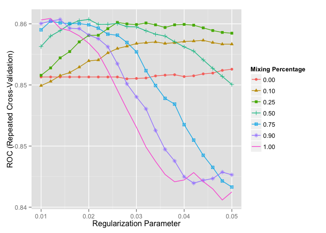

```r
#Training Methodology Parameters
trcontrol <- trainControl(method = "repeatedcv",
                          number = 10,
                          repeats = 3,
                          summaryFunction = twoClassSummary,
                          classProbs = TRUE)

##Tuning Parameters, alpha (percent lasso vs ridge regression)
# and lambda (coefficient penalty)
glmnGrid <- expand.grid(alpha=c(0, 0.1, 0.25, 0.5, 0.75, 0.9, 1),
                        lambda=seq(0.01, 0.05, length = 21))

##Train Model
set.seed(1237)
glmnTrained <- train(trainResponse ~ .,
                     data=trainModel,
                     method = "glmnet",
                     tuneGrid = glmnGrid,
                     trControl = trcontrol,
                     metric = "ROC",
                     family = "binomial")


ggplot(glmnTrained)
```

The model selection process uses area under the ROC curve as the variable to maximize. A perfect model has an ROC value of 1, and a model that randomly guesses has an ROC value of 0.5. In general I pick the simplest model that doesn’t sacrifice too much predictive power. Here we see that the best model has a mixing parameter of 25% lasso (75% ridge regression) and a total penalty of 0.04. I will use these values when bootstrapping to better estimate error.

```r
trcontrolFin <- trainControl(method="boot",
                             number=100,
                             summaryFunction=twoClassSummary,
                             classProbs=TRUE)

glmnGridFin <- expand.grid(alpha = 0.25,
                           lambda = 0.04)
set.seed(57142)
glmnTrainedFin <- train(valResponse ~ .,
                        data=valModel,
                        method="glmnet",
                        tuneGrid=glmnGridFin,
                        trControl=trcontrolFin,
                        metric="ROC",
                        family="binomial")
```

Once I have modeled the data using all seven algorithms, I will compare these bootstrapped error estimates to help select which model(s) to use. It is important to note that I use a separate data set here from the set used to tune the model. This is done because if we use the same data to both tune the model and predict the error, we end up biasing (specifically underestimating) the error rate of the model.

### Flexible Discriminant Analysis

Flexible discriminant analysis using a multivariate adaptive regression spline (say that ten times fast without falling asleep) is the next model on the list. As I said earlier, the training process is almost identical to training a logistic regression model so I don’t display the process. The biggest difference is that we tune over interaction degrees and how many terms to keep in the final model.

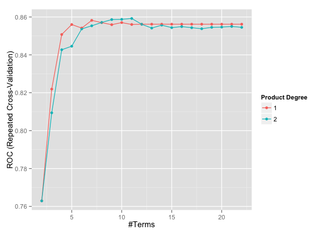

The simplest model with close to maximum accuracy used 5 terms and included no predictor interaction.

### PLS Discriminant Analysis

The tuning parameter for a partial least squares discriminant model is the number of components to use.

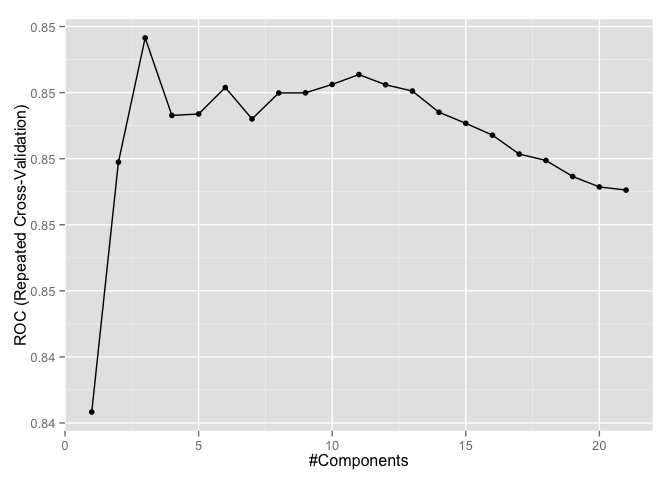

The best model used 3 pls components and had an ROC approaching 0.85.

### Boosted Trees

There are three tuning parameters for boosted trees: tree depth, number of trees, and the shrinkage coefficient of each tree added to the model.

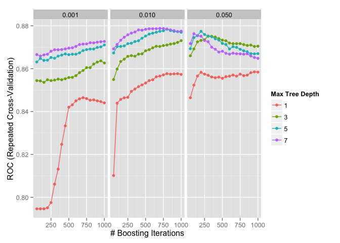

### Random Forest

We tune random forests over the number of predictors randomly available to the trees at each split.

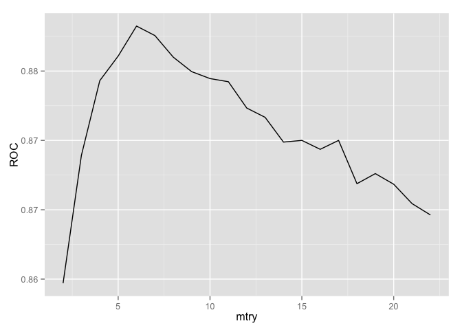

The final model used 6 random predictors at each split.

### C5.0

C5.0 models are trained over whether the tree is winnowed, whether the final model is a tree or a series or rules, and how many trials (boosting iterations).

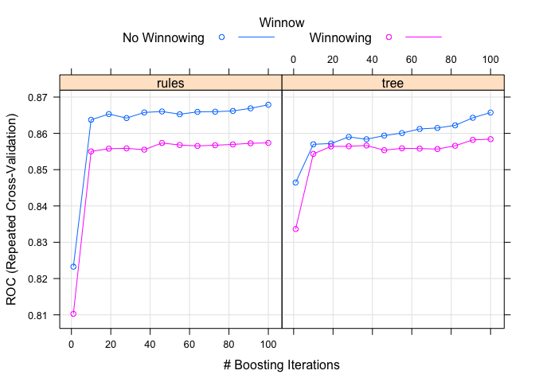

### Support Vector Machine

SVMs with a radial basis kernel function are tuned over the cost of incorrectly classifying an observation and on the scale of the kernel function (sigma).

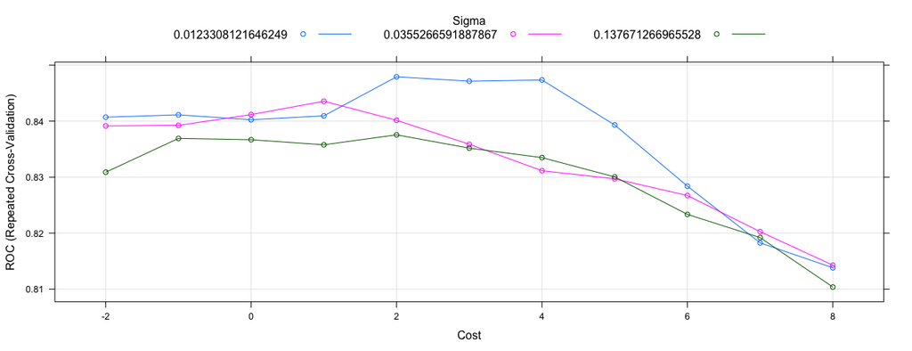

The best model had a cost of misclassifying of 2, and the smallest sigma value.

## Model Comparison and Selection

With all 7 models built, we can now compare their performance. I like to consider overall performance as well as performance on known subgroups.

### Overall Performance

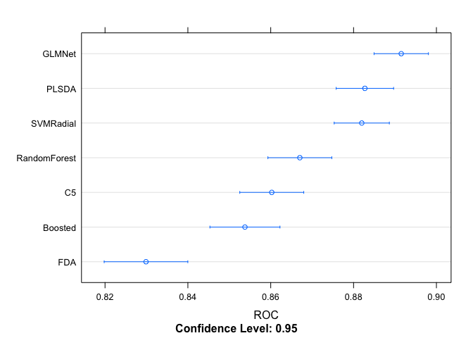

```r
set.seed(1234)

modelSet1 <-list(
    Boosted=bTreeTrainedFin,
    C5=c5TrainedFin,
    FDA=fdaTrainedFin,
    GLMNet=glmnTrainedFin,
    PLSDA=plsdaTrainedFin,
    RandomForest=rfTrainedFin,
    SVMRadial=svmTrainedRadFin)

resamps <- resamples(modelSet1)

dotplot(resamps, metric = "ROC")
```

We see that the penalized logistic regression model (glmnet) had the largest area under the ROC curve, which is nice because of all the models logistic regression results are the easiest to interpret. Here is a comparable chart to the last, but with the individual bootstrap error results superimposed to give an idea of spread.

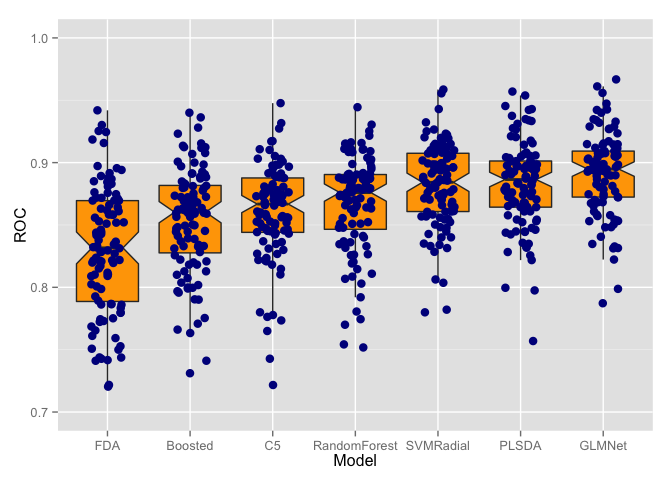

```r
rocGrid <- data.frame(matrix(ncol = 0, nrow = 100))
for (i in 1:length(modelSet1)){
    rocGrid <- cbind(rocGrid,modelSet1[[i]]$resample$ROC)

}
colnames(rocGrid) <- names(modelSet1[1:length(modelSet1)])
rocGrid <- rocGrid[,order(colMeans(rocGrid,na.rm=T))]
rocMelt <- melt(rocGrid,id=NULL)
modelfit <- ggplot(data=rocMelt,aes(x=variable,y=value)) +
    geom_boxplot(fill="orange",notch=T,outlier.size=0)
modelfit + geom_point(position = position_jitter(w = 0.2),
                      size = 3, color = "darkblue") +
    scale_y_continuous(limits=c(.7,1))+ylab("ROC")+xlab("Model")
```

This is a macro-look at model-performance, but to get a better picture of performance I like to consider each model’s ability to predict known subgroups, so let’s evaluate further.

### Evaluating Performance with Shiny

To evaluate model performance for specific cases, I built a widget in R that lets us see the predicted probabilities of survival for different individuals. Here is a [link to the widget](https://jamieanderson.shinyapps.io/Titanic/).

The widget provides an easy way to evaluate model calibration. Given a set of characteristics, we can see the survival probability each model predicts. I also provided several default passenger archetypes for convenience.

Recall from earlier exploration there were several criteria an effective model needs to encompass:

1. Women survived much more frequently than men.
2. Third-class women had much worse odds of survival than their counterparts in the first or second class.
3. Among women in the third class, departing from Southampton greatly reduced odds of survival.
4. First class men had much better odds of survival than second or third-class men.
5. **Age** and **travelerfare** impacted whether a first class man survived
6. **Age**, **travelerfare**, **familydied** impacted whether a third class women survived

I analyzed each of these criteria using the widget and determined if each model accurately encompassed these relationships.

1. **Boosted Tree**  
   *Strong Performance: 1, 2, 5, 6*  
   Week Performance: 3, 4
2. **C5.0**  
   *Strong Performance: 1, 2, 4, 5,*  
   Week Performance: 3, 6
3. **Flexible Discriminant Analysis**  
   *Strong Performance: 2*  
   Week Performance: 1, 3, 4, 5, 6
4. **Logistic Regression**  
   *Strong Performance: 1, 2, 3*  
   Week Performance: 4, 5, 6
5. **PLS Discriminant Analysis**  
   *Strong Performance: 1*  
   Week Performance: 2, 3, 4, 5, 6
6. **Random Forest**  
   *Strong Performance: 1, 2, 4, 5, 6*  
   Week Performance: 3
7. **Support Vector Machine**  
   *Strong Performance: 1, 2, 3*  
   Week Performance: 4, 5, 6

For the final model I will average several models together. We can immediately rule out **PLSDA** and **FDA**, because neither gave reliable probability estimates for most of the subcategories we were worried about.

**SVMs** and **Logistic Regression**, were good at the same categories, and logistic was better overall, so I will use **Logistic Regression** in the final model. The **Random Forest** model was good at 5 of 6 categories, so I will include it in the final model as well. Because **C5** and the **Boosted Tree** models offered similar calibration to the **Random Forest** model, but had weaker overall performance, I exclude them from the average.

And so, my final model will be an average of penalized **Logistic Regression** and the **Random Forest** Model. Next I will retrain each model using the full training set.

## Final Model Building

First I’ll explain the theory behind penalized logistic regression and random forest models. Then I will tune the logistic and random forest models. After that’s done I will build a function that averages the two. I can then analyze the performance of this hybrid model and recalibrate if necessary.

### Explaining Penalized Logistic Regression

First let me briefly explain logistic regression, and then I will explain the penalized (or sometimes regularized) component. Logistic regression is used in place of linear regression for classification problems.

Linear regression doesn’t work for classification problems for several reasons. Namely, linear regression will predict numbers between negative infinity and positive infinity. For classification problems, we want probability estimates, which are instead bound by 0 to 100%. If we were to use linear regression, some observations would be predicted to have probabilities less than 0 or greater than 100%. Obviously this doesn’t make sense, and so we shouldn’t model probabilities with linear regression.

If probability isn’t bound by negative infinity and positive infinity is there any way to make it? What if instead of probability, we modeled the odds of an event? Recall that if an event has a 75% chance of happening, it has odds of 3:1 or just 3; we just divide the probability of success by the probability of failure. If another event has a 99.99% probability of occurring it has odds of 9999:1 or 9999, because 0.9999/0.0001 equals 9999. As you can imagine odds can increase all the way to positive infinity. But the lowest odds possible are still 0 and so they cannot be negative, and therefore linear regression still isn’t appropriate.

What if you were to take the log of the odds? Remember, the odds on the positive side approached infinity, and the limit of log(x) as x approaches infinity is also infinity, so we are good on the upper boundary. As for the lower boundary the limit of log(x) as x approaches 0 is negative infinity. The log of odds is bound by negative infinity and positive infinity, which is the same as linear regression, so it is appropriate to construct the following model:

$log(odds) = \beta_0 + \beta_1*x_1 + \beta_2*x_2 + ... + \beta_n*x_n$

This is the logistic regression formula. We can make this more detailed by subbing in for the odds:

$log(\frac{p}{1-p}) = \beta_0 + \beta_1*x_1 + \beta_2*x_2 + ... + \beta_n*x_n$

With some basic algebra, we can rewrite this to solve for the probability (p):

$p = \frac{e^{\beta_0 + \beta_1*x_1 + \beta_2*x_2 + ... + \beta_n*x_n}}{1+e^{\beta_0 + \beta_1*x_1 + \beta_2*x_2 + ... + \beta_n*x_n}}$

What I just elaborated on is logistic regression in its simplest form. I don’t want to go into the details here of how penalizing the model works, but the purpose of penalizing the model is to prevent [overfitting the model](http://ecs.victoria.ac.nz/foswiki/pub/Courses/COMP307_2014T1/Lect13-team1/307im3.png) (third diagram) to the training set. Essentially, when building the model, the algorithm penalizes more complex models, where complexity is defined by the inclusion of more terms and larger coefficients. When tuning the model we try penalties of varying levels, and pick whichever creates a model that best generalizes to data not used in constructing the model. There are also a few different types of penalties that can be used. These can also be incorporated into the tuning process, but further explanation is beyond the scope of this report.

### Explaining Random Forest Models

Random forest models are a significant improvement on a basic decision tree classifier. If you aren’t familiar, a decision tree is a method of classifying observations using logical conditions based on the predictors.

A decision tree starts by searching all predictors for the logical split that separates the two categories being classified the best. The algorithm then keeps splitting each subgroup on the predictors until the groups are perfectly classified. [Here’s](http://www.nltk.org/images/decision-tree.png) an example of what a decision tree looks like.

The mathematical function used to determine the best split involves entropy:

$-{p_1}log_2(p_1)-p_2log_2(p_2)$

Where $p_1$ is the percentage of the group is the first category and $p_2$ is the percentage of the group belonging to the second category. The larger the entropy value the more mixed (and less confident we are predicting) a group is, so we want to minimize entropy. When a group is evenly split entropy will be $-0.5log_2(0.5)-0.5log_2(0.5)$ or 1. If a group is perfectly homogeneous (made up of only one category) the entropy will be $0log_2(0)-log_2(1)$ which simplifies to 0. So entropy is on a scale from 0 to 1, where 0 indicates perfect classification and 1 represents a 50/50 split.

The decision tree algorithm considers which split minimizes the entropy of the model the most when considering possible split variables. Once a split is made, the decision tree keeps further splitting each subgroup. Then the tree makes predictions based on the majority class in each final node.

The problem with decision trees is that they tend to overfit the model to the training set. If just a few observations were different, the first split condition may change, which would then every subsequent split condition to change. This causes decision trees to be highly unstable from sample to sample.

Random forest are a way to stabilize decision tree modeling. The algorithm repeatedly bootstraps the data and builds single decision trees on each resample. The prediction are then averaged together. This whole process is known as bootstrap aggregating (or bagging for short).

Random forests take this one step further. While bagging helps, the trees are often very similar to each other, meaning the final bagged model can still be unstable. Random forests have a tuning parameter `mtry` that restricts the number of predictors available to the algorithm at each split. So if `mtry` is set to 5, only 5 of the predictors can be used at a given split. This simple modification greatly uncorrelates the trees from one another. With dissimilar trees, the final predictions are much more stable. `mtry` is the main tuning parameters of random forest models along with the number of bootstrap resamples (but generally 500 trees is more than enough).

### Tuning

This process is similar to what we already did, except we use the full set and don’t do any bootstrapping.

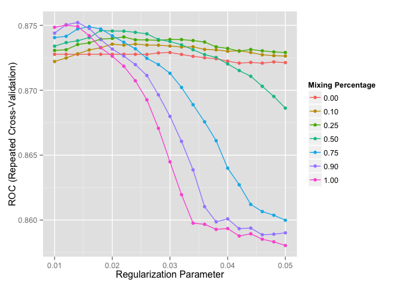

```r
options(digits=7)
fullResponse <- revalue(fullResponse, c("0" = "Died", "1" = "Survived"))
trcontrol <- trainControl(method = "repeatedcv",
                          number = 10,
                          repeats = 5,
                          summaryFunction = twoClassSummary,
                          classProbs = TRUE)

glmnGrid <- expand.grid(alpha=c(0, 0.1, 0.25, 0.5, 0.75, 0.9, 1),
                        lambda=seq(0.01, 0.05, length = 21))

set.seed(2523)
glmnTrained2 <- train(x=fullModel[, -1],
                     y=fullResponse,
                     method = "glmnet",
                     tuneGrid = glmnGrid,
                     trControl = trcontrol,
                     metric = "ROC",
                     family = "binomial")


ggplot(glmnTrained2)
```

```r
coefs <- coef(glmnTrained2$finalModel,glmnTrained2$bestTune$lambda)
nzCoefIndex <- predict(glmnTrained2$finalModel,
                       s=glmnTrained2$bestTune$lambda,
                       type="nonzero")

nzCoefs <- coefs[c(1,nzCoefIndex$X1+1),,drop=FALSE]
nzCoefs
```

```
## 13 x 1 sparse Matrix of class "dgCMatrix"
##                       1
## (Intercept)       1.218
## age              -0.284
## fare              0.048
## siblings         -0.594
## children         -0.066
## familydied       -0.469
## travelerfare      0.117
## pclass.L          1.127
## sexmale          -2.004
## embarkedC         0.222
## passTitleMaster.  1.904
## passTitleMr.     -0.771
## passTitleRev.    -0.846
```

Recall that we set a married first class female passenger from Southampton to be the default class. Holding the other variables at their means, her odds of survival are **3.38 to 1** that she survived (in logistic regression we are predicting log odds, so we have to exponentiate), or a **77.17%** chance of surviving.

Since the predictors were scaled, we can compare coefficient magnitude. The three predictors most detrimental to survival are:

1. Being a man
2. If you are male, being a reverend
3. If you are male, being an adult (Title = Mr.)

The two most beneficial traits were:  
1. If you were male, being a boy (title = Master)  
2. Being in a higher social class

Now we can train the random forest model and discover which variables were most predictive for that model.

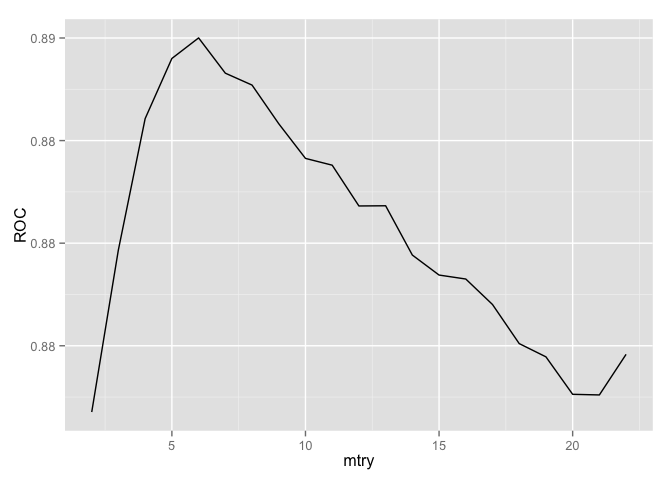

```r
rfGrid <- expand.grid(mtry=seq(2,ncol(trainModel),by=1))

set.seed(9843)
rfTrained <- train(x=fullModel[,-1],
                   y=fullResponse,
                   method="rf",
                   metric="ROC",
                   tuneGrid=rfGrid,
                   trControl=trcontrol,
                   importance=TRUE,
                   ntrees=500)

ggplot(data=rfTrained$results,aes(x=mtry,y=ROC))+geom_line()
```

The random forest model with the highest ROC occurred when `mtry` equaled 6, which if you recall is the number of predictors randomly available to the algorithm at each split.

```r
varImportance <-varImp(rfTrained)$importance
varImportance <- data.frame(variable=rownames(varImportance),varImportance)
varImportance <- varImportance[order(-varImportance[,2]),]
rownames(varImportance) <- NULL
varImportance[,2] <- round(varImportance[,2],3)
varImportance
```

```
##              variable  Died Survived
## 1             sexmale 100.0    100.0
## 2        passTitleMr.  85.3     85.3
## 3        travelerfare  82.1     82.1
## 4                 age  78.1     78.1
## 5            pclass.L  78.1     78.1
## 6                fare  71.7     71.7
## 7          familydied  69.1     69.1
## 8    passTitleMaster.  52.6     52.6
## 9            siblings  48.0     48.0
## 10           pclass.Q  43.0     43.0
## 11          embarkedQ  38.0     38.0
## 12      passTitleRev.  35.8     35.8
## 13            parents  29.6     29.6
## 14     passTitleMiss.  27.7     27.7
## 15        familylived  25.0     25.0
## 16            spouse1  22.9     22.9
## 17          embarkedC  19.2     19.2
## 18           children  16.5     16.5
## 19 passTitleMilitary.  11.3     11.3
## 20       passTitleDr.   3.7      3.7
## 21 passTitleNobility.   0.0      0.0
```

Unfortunately we can’t extract coefficients from a random forest model, but we can get a measure of how important each predictor is in terms of impacting survival probability, and here we see that gender is again the most important, followed by being an adult male. Interesting however, is that **travelerfare** and **age** are the next most important variables, which wasn’t the case for logistic regression.

### Combining Model Predictions

We can now create a function that takes observations and outputs an average of the two models’ predicted probabilities of survival. Here is a function that will do just that.

```r
calcPreds <- function(samples=fullModel[,-1]){
    rPred <- predict(rfTrained$finalModel,
                     newdata=samples,
                     type="prob")[,2]
    gPred <- predict(glmnTrained2$finalModel,
                     newx=samples,
                     type="response",
                     s=glmnTrained2$bestTune$lambda)
    rowMeans(cbind(rPred,gPred))
}
modelPreds <- calcPreds()
```

### Evaluating Model Performance

Next let’s analyze how well this final model fit out training set. A confusion matrix is often enlightening, so let’s start there.

```r
#Calculate Predicted Classes
predClasses <- ifelse(modelPreds >= 0.5, "Survived","Died")
#Confusion Matrix
confusionMatrix(factor(predClasses,levels=c("Died","Survived")),fullResponse)
```

```
## Confusion Matrix and Statistics
##
##           Reference
## Prediction Died Survived
##   Died      527       56
##   Survived   22      286
##
##                Accuracy : 0.912
##                  95% CI : (0.892, 0.93)
##     No Information Rate : 0.616
##     P-Value [Acc > NIR] : < 2e-16
##
##                   Kappa : 0.811
##  Mcnemar's Test P-Value : 0.000187
##
##             Sensitivity : 0.960
##             Specificity : 0.836
##          Pos Pred Value : 0.904
##          Neg Pred Value : 0.929
##              Prevalence : 0.616
##          Detection Rate : 0.591
##    Detection Prevalence : 0.654
##       Balanced Accuracy : 0.898
##
##        'Positive' Class : Died
##
```

The model predicted 91% of training set cases correctly. If the model predicted a passenger lived, it was correct 92.9% of the time, and if it predicted a passenger died it was correct only 90.4% of the time, so we can be slightly more confident in predictions of surviving, but not by much.

### Calibration

The final tweak I like to make to models is to calibrate their probabilities. The accuracies we just looked at only care if a probability was above or below 50%, so a passenger with a 40% chance of survival is treated the same as a passenger with a 1% chance of survival, but for a model to be truly predictive, we would like individuals predicted to survived 7% of the time, to actually survive 7% of the time.

A calibration plot graphs the predicted survival probability on the x-axis vs actual survival proportions of the training set on the y-axis. Ideally we’d want a perfectly straight line going from (0%,0%) to (100%,100%).

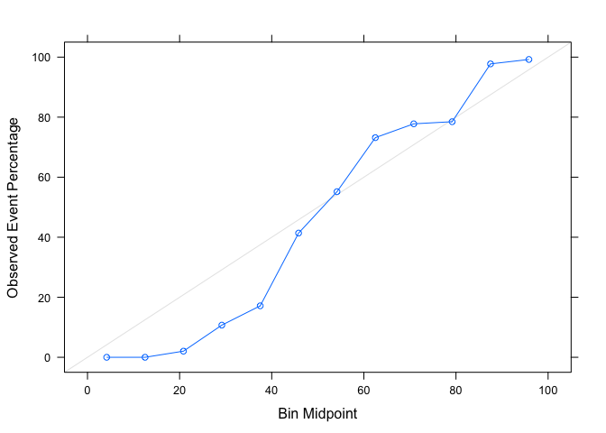

```r
cal <- calibration(fullResponse~(1-modelPreds),cuts=12)
plot(cal)
```

We can see very clearly that the model is overly optimistic for passengers with predicted probabilities lower than 50% and slightly too pessimistic for predictions between 50-80%. We can remedy this by fitting a final model (last model, I promise!!) to the probabilities.

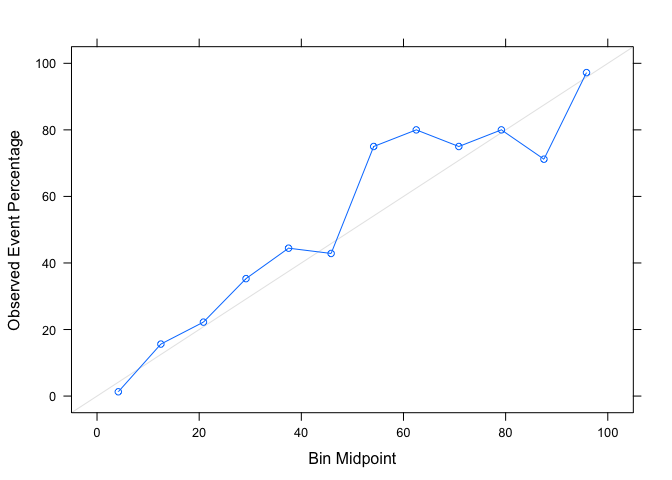

```r
calData <- data.frame(survived = fullResponse, prob = modelPreds)
sigmoidalCal <- glm(survived ~ prob, data = calData, family = "binomial")

sigProbs <- predict(sigmoidalCal, type = "response")

calSig <- calibration(fullResponse ~ I(1 - sigProbs), cuts = 12)
plot(calSig)
```

This model no longer overestimates survival probabilities from 0 to 50% and has about the same calibration from 50% on. Therefore we can say it is a more calibrated (albeit only slightly) model and it is what we will use to predict the test set. With that done, let’s make some predictions!

## Predicting The Test Set

Now we can finally make prediction on the test set and make a submission to Kaggle. We do have to first convert the test set to the correct formatting used in our model. That means creating the new variables, imputing missing data, scaling according to the means and standard deviation of our training set, and then dummy-coding variables. Since this is just a repetition of what I showed earlier, I hide the 200 lines of code, but the first 3 rows are shown to verify correct formatting.

```r
head(testModel,3)
```

```
##   (Intercept)  age  fare siblings parents children travelerfare
## 1           1 0.18 -0.25    -0.16   -0.17    -0.15          5.6
## 2           1 0.65 -0.25    -0.16   -0.17    -0.15          2.4
## 3           1 1.21 -0.23    -0.16   -0.17    -0.15          7.0
##   familylived familydied pclass.L pclass.Q sexmale embarkedC embarkedQ
## 1        0.97      -0.26 -7.1e-01     0.41       1         0         1
## 2       -0.24      -0.28 -7.1e-01     0.41       0         0         0
## 3       -0.24      -0.28 -7.9e-17    -0.82       1         0         1
##   passTitleMiss. passTitleNobility. passTitleDr. passTitleMaster.
## 1              0                  0            0                0
## 2              0                  0            0                0
## 3              0                  0            0                0
##   passTitleMr. passTitleRev. passTitleMilitary. spouse1
## 1            1             0                  0       0
## 2            0             0                  0       1
## 3            1             0                  0       0
```

Looks good, so now we can apply this to the test set and submit to Kaggle.

```r
testProbs <- calcPreds(testModel[,-1])
calibratedProbs <- predict(sigmoidalCal,data.frame(prob=testProbs),type="response")
testPreds <- ifelse(calibratedProbs >= 0.5, 1, 0)
submission <- data.frame(PassengerId = passengerid, Survived = testPreds)
write.csv(submission, "submissionFinal.csv", row.names = FALSE)
```

And that about wraps it up. Phew!